# Raport PD3 - Jak wizualizacja wpływa na odbiór danych?

Mira Wróblewska

## Wstęp

Celem tego badania było sprawdzenie wpływu typu wykresu i palety barw na czytelność danych. Badanie zostało przeprowadzone w formie ankiety, a dane do wykresu użytego w badaniu zostały wzięte ze strony Kaggle. Przypuszczalnie forma wykresu kołowego wpłynie negatywnie na odbiór danych na nim zawartych. Grupa badawcza jest zróżnicowana nie tylko pod względem wieku, ale też wykształcenia.

## Wykres użyty w badaniu

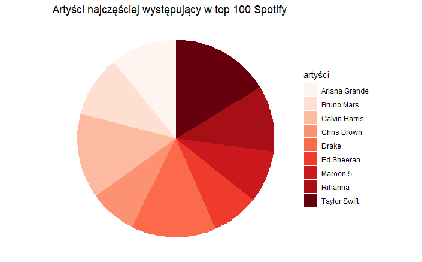

## Przebieg eksperymentu

Zostały zadane trzy pytania:

### Który artysta pojawia się najczęściej w zestawieniu top 100 Spotify?

Z tym pytaniem ankietowani nie mieli problemu i wszyscy oprócz jednej osoby (15 z 16) odpowiedzieli na nie prawidłowo. Jedyną błędną odpowiedzią była odpowiedź “Drake”. Odpowiedzi byly w znacznej większosci prawidłowe ponieważ różnica miedzy poprawną odpowiedzią a resztą była na tyle duża że nawet na źle przygotowanym wykresie ciężko było sie pomylić.

### Czyje piosenki znalazły się więcej razy w zestawieniu top 100 Spotify?

Do wyboru były odpowiedzi “Bruno Mars”, “Maroon 5” i “Znalazły się tyle samo razy”. W tym pytaniu zróżnicowanie odpowiedzi było już większe co można zobaczyć na wykresie.

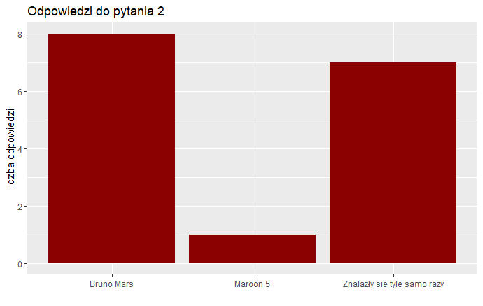

Ciekawym jest aż tak liczny udział w odpowiedziach opcji “znalazły się tyle samo razy”. Prawidłową odpowiedzią było “Bruno Mars” wystąpił on 13 razy a “Maroon 5” 11 razy. Błędy w odpowiedziach wynikają z tego że ciężko na podstawie kątów w wykresie kołowym ocenić proporcje.

### Piosenki Taylor Swift znalazły się w zestawieniu 21 razy. Ile razy znalazły się w nim piosenki Drake’a?

Tutaj ankietowani mogli wpisywac własne odpowiedzi i jak widać zróżnicowanie jest bardzo duże. Prawidłową odpowiedzią jest 18. Jest całkiem sporo odpowiedzi zbliżonych do poprawnej, ale tez zaskakująco dużo skrajnie odległych co moze świadczyc o tym, że ankietowani analizowali zupełnie inny wycinek wykresu. Widzimy więc, że źle dobrana paleta kolorów może spowodować zupełne wypaczenie odbioru danych przez co mogą być wyciągane błedne wnioski.

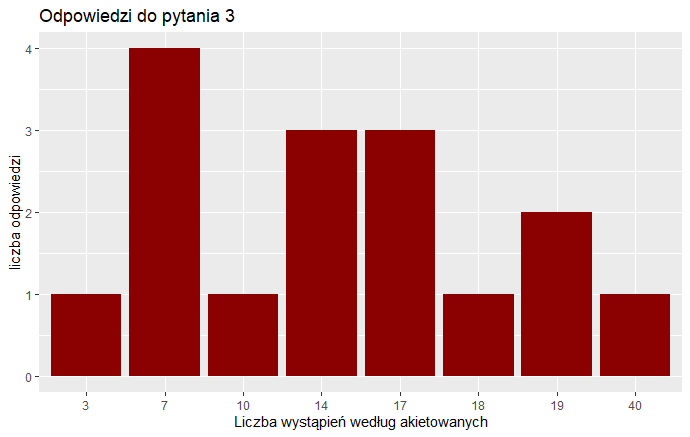

## Lepsza wizualizacja danych

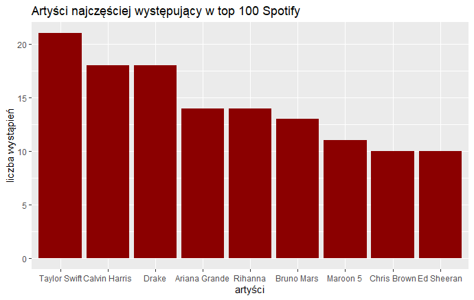

## Wnioski

Widzimy, że odpowiedzi na zadane pytania są oczywiste patrząc na prawidłowo przygotowaną wizualizację. Kolory nie mają wpływu na odbiór danych a relacje wielkościowe między artystami są o wiele wyraźniej zaznaczone.